# detección_de_señales_de_tráfico_con_yolov8

## **| Traffic Signs Detection Using**

YOLOv8

[figure not shown]

## **1 | Introduction**

**1.1 |** Object Detection

**Computer vision** is a field of artificial intelligence that focuses on teaching computers to interpret and understand visual information. One popular and powerful technique used in computer vision for object detection is called **YOLO**, which stands for "You Only Look Once".

YOLO aims to identify and locate objects in an image or video stream in real-time. Unlike traditional methods that rely on complex pipelines and multiple passes, YOLO takes a different approach by treating object detection as a single regression problem.

This algorithm divides the input image into a grid and predicts bounding boxes and class probabilities for objects within each grid cell. It simultaneously predicts the class labels and their corresponding bounding boxes, making it incredibly efficient and fast. YOLO is known for its real-time performance, enabling it to process images and videos at impressive speeds.

By leveraging **deep convolutional neural networks**, YOLO can learn to recognize a wide range of objects and accurately localize them within an image. It can detect multiple objects of different classes simultaneously, making it particularly useful for applications where **real-time processing** and high detection accuracy are crucial, such as **autonomous driving**, **video surveillance**, and **robotics**.

**1.2 |** YOLOv8

**YOLOv8** is the latest version of the YOLO AI model developed by **Ultralytics**, which has shown effectiveness in tackling tasks such as **classification**, **object detection**, and **image segmentation**. **YOLOv8 models** are fast, accurate, and easy to use, making them ideal for various object detection and image segmentation tasks. They can be trained on large datasets and run on diverse hardware platforms, from **CPUs** to **GPUs**. YOLOv8 *detection* models have no suffix and are the default YOLOv8 models, i.e. **yolov8n.pt** ,and are pre-trained on COCO. See [Detection Docs](https://docs.ultralytics.com/tasks/detect/) for full details.

**1.3 |** Study Aim

Implementing **Sign Detection** using **YOLOv8** holds tremendous potential across a wide range of practical applications. For example, it can greatly enhance **traffic management systems**, allowing for the efficient detection and recognition of various traffic signs. This technology can play a vital role in improving road safety by enabling vehicles to accurately interpret and respond to the information conveyed by road signs. Moreover, sign detection using YOLOv8 can assist in urban planning and infrastructure development by analyzing the presence and condition of signs in different areas

By undertaking this project, I aimed to harness the power of YOLOv8 to develop a **reliable signs detection solution** with the potential to improve various domains that rely on precise and efficient signs identification.

## **2 | Install And Import Essential Libreries**

```python
# ==========================
# 🔧 Instalar librerías necesarias
# ==========================
!pip install -q kagglehub ultralytics easyocr
!pip install ultralytics

# ==========================
# 📦 Descargar dataset desde KaggleHub
# ==========================
import kagglehub

# Descargar el dataset al entorno local
dataset_path = kagglehub.dataset_download("pkdarabi/cardetection")

print("✅ Dataset descargado en:", dataset_path)
```

[output not shown]

```python
# Import Essential Libraries
import os
import random
import pandas as pd
from PIL import Image
import cv2
from ultralytics import YOLO
from IPython.display import Video
import numpy as np
import matplotlib.pyplot as plt
import seaborn as sns
sns.set(style='darkgrid')
import pathlib
import glob
from tqdm.notebook import trange, tqdm
import warnings
import torch
import matplotlib.pyplot as plt

warnings.filterwarnings('ignore')
```

```
Creating new Ultralytics Settings v0.0.6 file ✅
View Ultralytics Settings with 'yolo settings' or at '/root/.config/Ultralytics/settings.json'
Update Settings with 'yolo settings key=value', i.e. 'yolo settings runs_dir=path/to/dir'. For help see https://docs.ultralytics.com/quickstart/#ultralytics-settings.
```

```python
# Configure the visual appearance of Seaborn plots
sns.set(rc={'axes.facecolor': '#eae8fa'}, style='darkgrid')
```

## **3 | Dataset**

**3.1 |** Show Original Images Before Detect

**3.1.1. Show Some Images From TrainSet**

[figure not shown]

```python
# Ruta a las imágenes descargadas con kagglehub
image_dir = os.path.join(dataset_path, "car", "train", "images")

num_samples = 9
image_files = os.listdir(image_dir)

# Muestra aleatoriamente algunas imágenes
image_files = os.listdir(image_dir)
sample_images = random.sample(image_files, 9)

fig, axes = plt.subplots(3, 3, figsize=(12, 12))
for idx, img_name in enumerate(sample_images):
    img_path = os.path.join(image_dir, img_name)
    image = plt.imread(img_path)
    ax = axes[idx // 3, idx % 3]
    ax.imshow(image)
    ax.set_title(img_name)
    ax.axis('off')

plt.tight_layout()
plt.show()
```

**3.1.2. Get Shape Of An Image For Using In Training Step**

```python
# Get the size of the image
image = cv2.imread("/kaggle/input/cardetection/car/train/images/00000_00000_00012_png.rf.23f94508dba03ef2f8bd187da2ec9c26.jpg")
h, w, c = image.shape
print(f"The image has dimensions {w}x{h} and {c} channels.")
```

```
The image has dimensions 416x416 and 3 channels.
```

## **4 | Try Pre-trained YOLOv8 For Detect Traffic Signs**

```
Downloading https://github.com/ultralytics/assets/releases/download/v8.3.0/yolov8n.pt to 'yolov8n.pt'...
```

```
image 1/1 /kaggle/input/cardetection/car/train/images/FisheyeCamera_1_00228_png.rf.e7c43ee9b922f7b2327b8a00ccf46a4c.jpg: 640x640 (no detections), 7.9ms
Speed: 12.0ms preprocess, 7.9ms inference, 113.4ms postprocess per image at shape (1, 3, 640, 640)
```

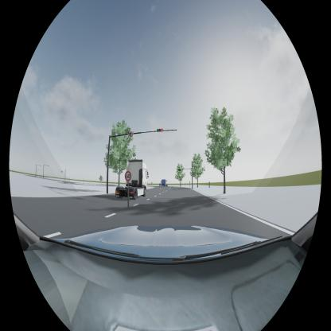

```python
# Use a pretrained YOLOv8n model
model = YOLO("yolov8n.pt")

# Use the model to detect object
image = "/kaggle/input/cardetection/car/train/images/FisheyeCamera_1_00228_png.rf.e7c43ee9b922f7b2327b8a00ccf46a4c.jpg"
result_predict = model.predict(source = image, imgsz=(640))

# show results
plot = result_predict[0].plot()
plot = cv2.cvtColor(plot, cv2.COLOR_BGR2RGB)
display(Image.fromarray(plot))
```

## **5 | YOLOv8-Based Traffic Signs Detection Model**

**5.1 |** Model Training Using Customized Dataset Of Traffic Signs

**Mean Average Precision (mAP)** is a metric used to evaluate the effectiveness of object detection algorithms in identifying and locating objects within images. It takes into account both precision and recall across different categories. By calculating the Average Precision (AP) for each category and taking the average, mAP provides an overall assessment of the algorithm's performance.

If the obtained mAP after the final epoch is not satisfactory, there are several options available to improve the results:

- Extending the training process by increasing the number of **epochs**: Training for more epochs allows the model to learn more patterns and potentially improve its performance. You can specify a higher value for the --epochs argument when running the training command.
- Experimenting with different **parameter values**: You can try adjusting various parameters to see if they have a positive impact on the results. Some parameters to consider are:
- **Batch Size:** Changing the batch size can affect the convergence and generalization of the model. You can modify the --batch-size argument to find an optimal value.
- **Initial Learning Rate (lr0)**: The initial learning rate determines the step size at the beginning of the training process. You can tune the --lr0 parameter to control how quickly the model learns.
- **Learning Rate Range (lrf)**: The learning rate range determines the range of learning rates used during the training. Experimenting with different values for --lrf can help find a better learning rate schedule.
- **Selecting a different optimizer**: The optimizer is responsible for updating the model's parameters based on the calculated gradients. Changing the optimizer can sometimes lead to better convergence and results. Ultralytics YOLOv8 supports different optimizers such as SGD, Adam, and RMSprop. You can try using a different optimizer by modifying the --optimizer argument.

**5.1.1. Training Step**

```python
!pip install --upgrade ultralytics ray
```

```
Downloading ray-2.46.0-cp311-cp311-manylinux2014_x86_64.whl (68.5 MB)
   ━━━━━━━━━━━━━━━━━━━━━━━━━━━━━━━━━━━━━━━━ 68.5/68.5 MB 10.7 MB/s eta 0:00:00
```

```python
# Verificar dispositivo
device = 'cuda' if torch.cuda.is_available() else 'cpu'
print(f"🔍 Usando dispositivo: {device}")

# Cargar modelo YOLOv8n
model = YOLO('yolov8n.pt')

# Entrenar y guardar resultados
results = model.train(
    data="/kaggle/input/cardetection/car/data.yaml",
    epochs=15,
    batch=8,
    imgsz=416,
    device=device,
    save=True,        # <-- OJO: esto debe ser True para crear carpeta y archivo
    save_period=1,
    verbose=False,
)
```

[output not shown]

```
Overriding model.yaml nc=80 with nc=15

                   from  n    params  module                                       arguments
  0                  -1  1       464  ultralytics.nn.modules.conv.Conv             [3, 16, 3, 2]
  1                  -1  1      4672  ultralytics.nn.modules.conv.Conv             [16, 32, 3, 2]
  2                  -1  1      7360  ultralytics.nn.modules.block.C2f             [32, 32, 1, True]
  3                  -1  1     18560  ultralytics.nn.modules.conv.Conv             [32, 64, 3, 2]
  4                  -1  2     49664  ultralytics.nn.modules.block.C2f             [64, 64, 2, True]
  5                  -1  1     73984  ultralytics.nn.modules.conv.Conv             [64, 128, 3, 2]
  6                  -1  2    197632  ultralytics.nn.modules.block.C2f             [128, 128, 2, True]
  7                  -1  1    295424  ultralytics.nn.modules.conv.Conv             [128, 256, 3, 2]
  8                  -1  1    460288  ultralytics.nn.modules.block.C2f             [256, 256, 1, True]
  9                  -1  1    164608  ultralytics.nn.modules.block.SPPF            [256, 256, 5]
 10                  -1  1         0  torch.nn.modules.upsampling.Upsample         [None, 2, 'nearest']
 11             [-1, 6]  1         0  ultralytics.nn.modules.conv.Concat           [1]
```

[output cut: 17 more lines]

```
AMP: checks passed ✅
train: Fast image access ✅ (ping: 0.0±0.0 ms, read: 6.3±2.2 MB/s, size: 24.1 KB)
```

```
train: Scanning /kaggle/input/cardetection/car/train/labels... 3530 images, 3 backgrounds, 0 corrupt: 100%|██████████| 3530/3530 [00:31<00:00, 111.87it/s]
```

```
WARNING ⚠️ train: Cache directory /kaggle/input/cardetection/car/train is not writeable, cache not saved.
albumentations: Blur(p=0.01, blur_limit=(3, 7)), MedianBlur(p=0.01, blur_limit=(3, 7)), ToGray(p=0.01, method='weighted_average', num_output_channels=3), CLAHE(p=0.01, clip_limit=(1.0, 4.0), tile_grid_size=(8, 8))
val: Fast image access ✅ (ping: 0.0±0.0 ms, read: 6.0±2.7 MB/s, size: 20.7 KB)
```

```
val: Scanning /kaggle/input/cardetection/car/valid/labels... 801 images, 0 backgrounds, 0 corrupt: 100%|██████████| 801/801 [00:06<00:00, 120.60it/s]
```

```
WARNING ⚠️ val: Cache directory /kaggle/input/cardetection/car/valid is not writeable, cache not saved.
Plotting labels to runs/detect/train/labels.jpg...
optimizer: 'optimizer=auto' found, ignoring 'lr0=0.01' and 'momentum=0.937' and determining best 'optimizer', 'lr0' and 'momentum' automatically...
optimizer: AdamW(lr=0.000526, momentum=0.9) with parameter groups 57 weight(decay=0.0), 64 weight(decay=0.0005), 63 bias(decay=0.0)
Image sizes 416 train, 416 val
Using 2 dataloader workers
Logging results to runs/detect/train
Starting training for 15 epochs...

      Epoch    GPU_mem   box_loss   cls_loss   dfl_loss  Instances       Size
```

```
       1/15     0.492G     0.8468      3.117      1.083          5        416: 100%|██████████| 442/442 [00:53<00:00,  8.32it/s]
                 Class     Images  Instances      Box(P          R      mAP50  mAP50-95): 100%|██████████| 51/51 [00:06<00:00,  7.45it/s]
```

```
                   all        801        944      0.188      0.373      0.208      0.166
```

```
      Epoch    GPU_mem   box_loss   cls_loss   dfl_loss  Instances       Size
```

```
       2/15     0.602G     0.7568      2.307       1.03          3        416: 100%|██████████| 442/442 [00:48<00:00,  9.11it/s]
                 Class     Images  Instances      Box(P          R      mAP50  mAP50-95): 100%|██████████| 51/51 [00:04<00:00, 10.65it/s]
```

```
                   all        801        944      0.319      0.474      0.314      0.259
```

```
      Epoch    GPU_mem   box_loss   cls_loss   dfl_loss  Instances       Size
```

```
       3/15     0.617G     0.7356      2.051      1.014          2        416: 100%|██████████| 442/442 [00:47<00:00,  9.29it/s]
                 Class     Images  Instances      Box(P          R      mAP50  mAP50-95): 100%|██████████| 51/51 [00:05<00:00, 10.06it/s]
```

```
                   all        801        944      0.341      0.572      0.413      0.335
```

```
      Epoch    GPU_mem   box_loss   cls_loss   dfl_loss  Instances       Size
```

```
       4/15     0.635G     0.7308       1.85      1.005          4        416: 100%|██████████| 442/442 [00:46<00:00,  9.42it/s]
                 Class     Images  Instances      Box(P          R      mAP50  mAP50-95): 100%|██████████| 51/51 [00:05<00:00,  8.97it/s]
```

```
                   all        801        944      0.529      0.554      0.521      0.436
```

```
      Epoch    GPU_mem   box_loss   cls_loss   dfl_loss  Instances       Size
```

```
       5/15     0.652G     0.6943      1.632     0.9877          1        416: 100%|██████████| 442/442 [00:46<00:00,  9.48it/s]
                 Class     Images  Instances      Box(P          R      mAP50  mAP50-95): 100%|██████████| 51/51 [00:05<00:00,  8.94it/s]
```

```
                   all        801        944      0.574      0.572      0.614      0.513
```

```
Closing dataloader mosaic
albumentations: Blur(p=0.01, blur_limit=(3, 7)), MedianBlur(p=0.01, blur_limit=(3, 7)), ToGray(p=0.01, method='weighted_average', num_output_channels=3), CLAHE(p=0.01, clip_limit=(1.0, 4.0), tile_grid_size=(8, 8))

      Epoch    GPU_mem   box_loss   cls_loss   dfl_loss  Instances       Size
```

```
       6/15     0.668G     0.6468      1.404     0.9227          2        416: 100%|██████████| 442/442 [00:45<00:00,  9.62it/s]
                 Class     Images  Instances      Box(P          R      mAP50  mAP50-95): 100%|██████████| 51/51 [00:05<00:00,  9.99it/s]
```

```
                   all        801        944      0.639      0.726      0.724      0.608
```

```
      Epoch    GPU_mem   box_loss   cls_loss   dfl_loss  Instances       Size
```

```
       7/15     0.684G     0.6318      1.143     0.9174          3        416: 100%|██████████| 442/442 [00:46<00:00,  9.59it/s]
                 Class     Images  Instances      Box(P          R      mAP50  mAP50-95): 100%|██████████| 51/51 [00:04<00:00, 10.34it/s]
```

```
                   all        801        944      0.702      0.711      0.758      0.648
```

```
      Epoch    GPU_mem   box_loss   cls_loss   dfl_loss  Instances       Size
```

```
       8/15     0.701G     0.6001      0.979     0.9017          2        416: 100%|██████████| 442/442 [00:47<00:00,  9.38it/s]
                 Class     Images  Instances      Box(P          R      mAP50  mAP50-95): 100%|██████████| 51/51 [00:04<00:00, 10.61it/s]
```

```
                   all        801        944      0.758      0.771      0.803      0.693
```

```
      Epoch    GPU_mem   box_loss   cls_loss   dfl_loss  Instances       Size
```

```
       9/15     0.719G      0.599     0.8833     0.9024          3        416: 100%|██████████| 442/442 [00:46<00:00,  9.42it/s]
                 Class     Images  Instances      Box(P          R      mAP50  mAP50-95): 100%|██████████| 51/51 [00:04<00:00, 10.74it/s]
```

```
                   all        801        944      0.804      0.774      0.833      0.711
```

```
      Epoch    GPU_mem   box_loss   cls_loss   dfl_loss  Instances       Size
```

```
      10/15     0.734G     0.5825     0.7805     0.8952          2        416: 100%|██████████| 442/442 [00:47<00:00,  9.34it/s]
                 Class     Images  Instances      Box(P          R      mAP50  mAP50-95): 100%|██████████| 51/51 [00:04<00:00, 11.04it/s]
```

```
                   all        801        944      0.867      0.797       0.86      0.741
```

```
      Epoch    GPU_mem   box_loss   cls_loss   dfl_loss  Instances       Size
```

```
      11/15     0.752G     0.5687     0.7203     0.8913          2        416: 100%|██████████| 442/442 [00:46<00:00,  9.44it/s]
                 Class     Images  Instances      Box(P          R      mAP50  mAP50-95): 100%|██████████| 51/51 [00:04<00:00, 10.94it/s]
```

```
                   all        801        944      0.869      0.808      0.867      0.751
```

```
      Epoch    GPU_mem   box_loss   cls_loss   dfl_loss  Instances       Size
```

```
      12/15      0.77G     0.5526     0.6602     0.8895          2        416: 100%|██████████| 442/442 [00:46<00:00,  9.47it/s]
                 Class     Images  Instances      Box(P          R      mAP50  mAP50-95): 100%|██████████| 51/51 [00:05<00:00,  9.58it/s]
```

```
                   all        801        944      0.894      0.792      0.866      0.751
```

```
      Epoch    GPU_mem   box_loss   cls_loss   dfl_loss  Instances       Size
```

```
      13/15     0.787G     0.5418     0.6243     0.8825          2        416: 100%|██████████| 442/442 [00:46<00:00,  9.51it/s]
                 Class     Images  Instances      Box(P          R      mAP50  mAP50-95): 100%|██████████| 51/51 [00:05<00:00,  8.84it/s]
```

```
                   all        801        944      0.919      0.815      0.885      0.768
```

```
      Epoch    GPU_mem   box_loss   cls_loss   dfl_loss  Instances       Size
```

```
      14/15     0.803G     0.5311     0.5912     0.8745          3        416: 100%|██████████| 442/442 [00:46<00:00,  9.58it/s]
                 Class     Images  Instances      Box(P          R      mAP50  mAP50-95): 100%|██████████| 51/51 [00:05<00:00,  8.83it/s]
```

```
                   all        801        944      0.916      0.832      0.886       0.77
```

```
      Epoch    GPU_mem   box_loss   cls_loss   dfl_loss  Instances       Size
```

```
      15/15      0.82G     0.5189     0.5618     0.8715          2        416: 100%|██████████| 442/442 [00:46<00:00,  9.56it/s]
                 Class     Images  Instances      Box(P          R      mAP50  mAP50-95): 100%|██████████| 51/51 [00:05<00:00,  8.89it/s]
```

```
                   all        801        944      0.945      0.817      0.894      0.778
```

```
15 epochs completed in 0.220 hours.
Optimizer stripped from runs/detect/train/weights/last.pt, 6.2MB
Optimizer stripped from runs/detect/train/weights/best.pt, 6.2MB

Validating runs/detect/train/weights/best.pt...
Ultralytics 8.3.146 🚀 Python-3.11.12 torch-2.6.0+cu124 CUDA:0 (Tesla T4, 15095MiB)
Model summary (fused): 72 layers, 3,008,573 parameters, 0 gradients, 8.1 GFLOPs
```

```
                 Class     Images  Instances      Box(P          R      mAP50  mAP50-95): 100%|██████████| 51/51 [00:05<00:00,  8.78it/s]
```

```
                   all        801        944      0.943      0.816      0.893      0.777
Speed: 0.1ms preprocess, 1.5ms inference, 0.0ms loss, 1.6ms postprocess per image
Results saved to runs/detect/train
```

**5.1.2. Validation Step**

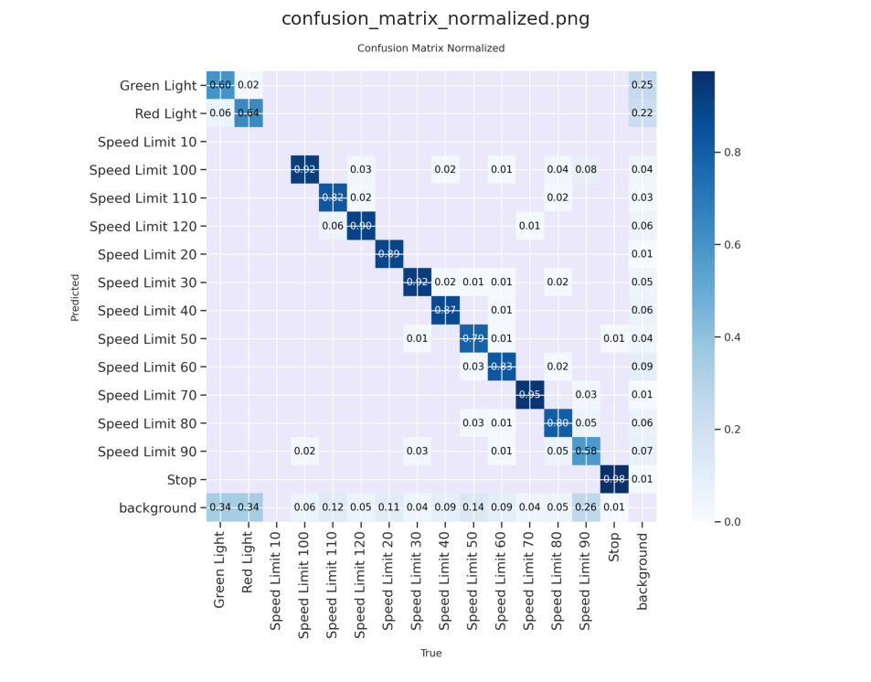

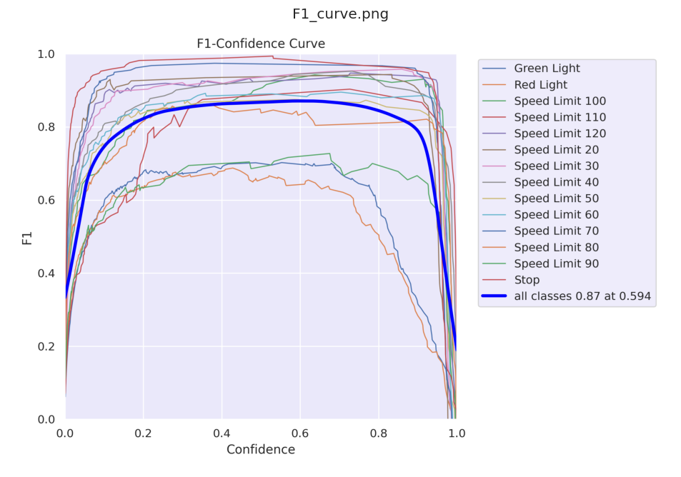

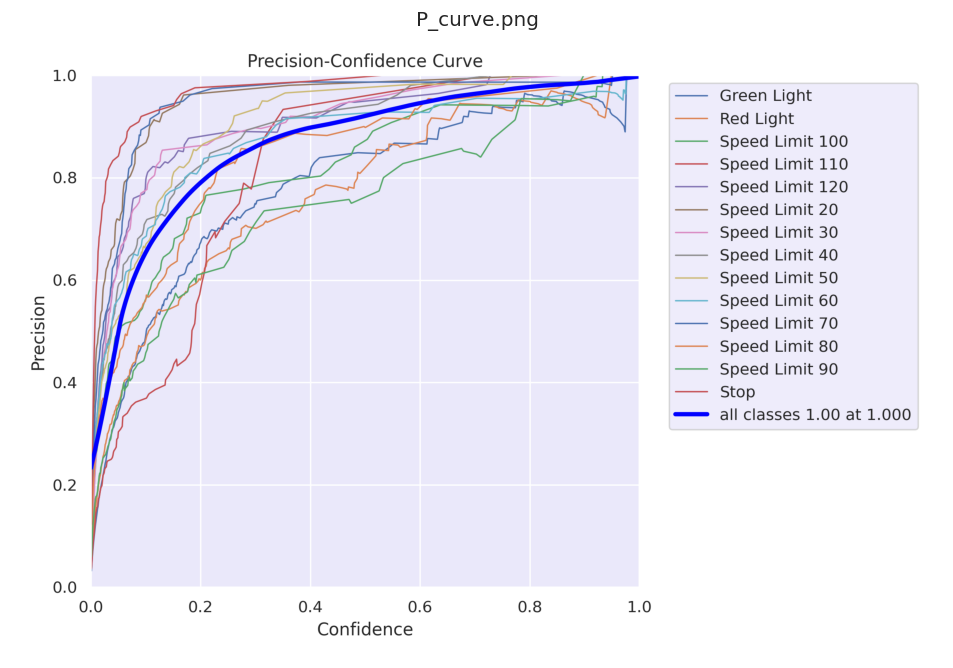

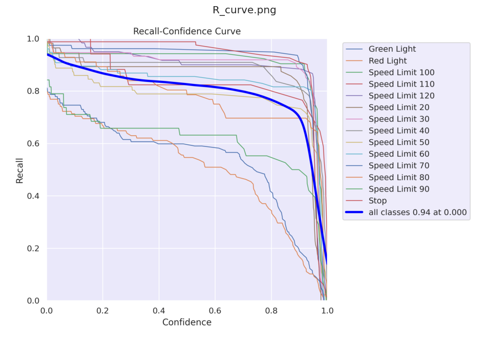

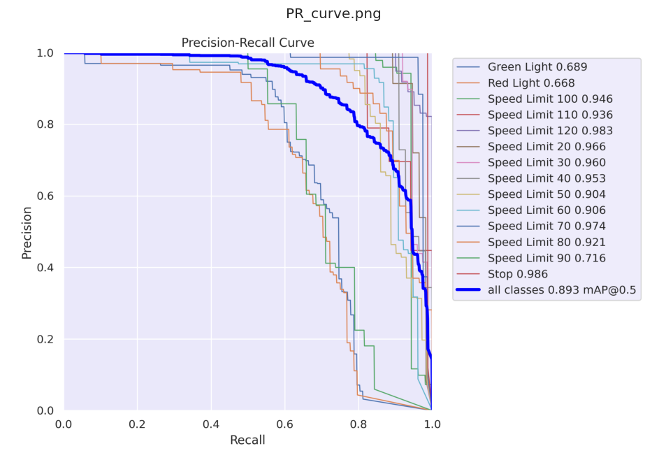

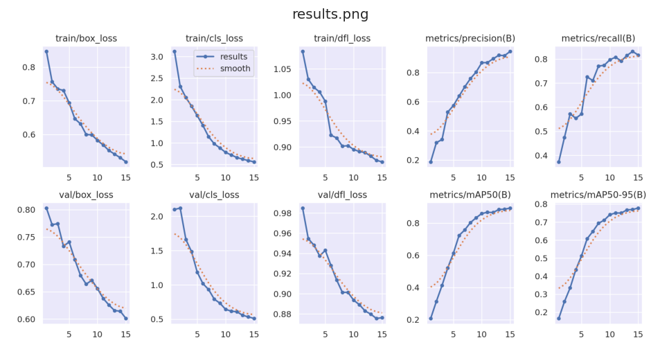

```python
def display_images(post_training_files_path, image_files):
    for image_file in image_files:
        image_path = os.path.join(post_training_files_path, image_file)

        if not os.path.exists(image_path):
            print(f"❌ Archivo no encontrado: {image_path}")
            continue

        img = cv2.imread(image_path)
        if img is None:
            print(f"⚠️ No se pudo leer la imagen (posiblemente vacía): {image_path}")
            continue

        img = cv2.cvtColor(img, cv2.COLOR_BGR2RGB)
        plt.figure(figsize=(10, 10), dpi=120)
        plt.imshow(img)
        plt.axis('off')
        plt.title(image_file)
        plt.show()

# Archivos a mostrar
image_files = [
    'confusion_matrix_normalized.png',
    'F1_curve.png',
    'P_curve.png',
    'R_curve.png',
    'PR_curve.png',
    'results.png'
]

# Ruta correcta sin /kaggle/working
post_training_files_path = 'runs/detect/train'

# Mostrar imágenes
display_images(post_training_files_path, image_files)
```

```python
results = pd.read_csv('/content/runs/detect/train/results.csv')
print(results.tail(10))
```

```
    epoch     time  train/box_loss  train/cls_loss  train/dfl_loss  \
5       6  323.986         0.64680         1.40430         0.92265
6       7  375.361         0.63183         1.14301         0.91735
7       8  427.571         0.60013         0.97898         0.90169
8       9  479.589         0.59896         0.88326         0.90244
9      10  531.873         0.58245         0.78048         0.89521
10     11  583.669         0.56867         0.72032         0.89129
11     12  635.997         0.55259         0.66025         0.88954
12     13  688.683         0.54179         0.62425         0.88245
13     14  740.935         0.53109         0.59119         0.87445
14     15  793.224         0.51885         0.56176         0.87152

    metrics/precision(B)  metrics/recall(B)  metrics/mAP50(B)  \
5                0.63859            0.72559           0.72364
6                0.70197            0.71076           0.75784
```

[output cut: 32 more lines]

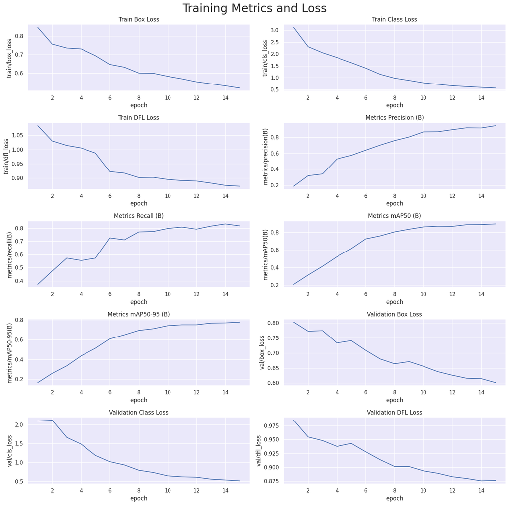

```python
# Read the results.csv file as a pandas dataframe
results.columns = results.columns.str.strip()

# Create subplots
fig, axs = plt.subplots(nrows=5, ncols=2, figsize=(15, 15))

# Plot the columns using seaborn
sns.lineplot(x='epoch', y='train/box_loss', data=results, ax=axs[0,0])
sns.lineplot(x='epoch', y='train/cls_loss', data=results, ax=axs[0,1])
sns.lineplot(x='epoch', y='train/dfl_loss', data=results, ax=axs[1,0])
sns.lineplot(x='epoch', y='metrics/precision(B)', data=results, ax=axs[1,1])
sns.lineplot(x='epoch', y='metrics/recall(B)', data=results, ax=axs[2,0])
sns.lineplot(x='epoch', y='metrics/mAP50(B)', data=results, ax=axs[2,1])
sns.lineplot(x='epoch', y='metrics/mAP50-95(B)', data=results, ax=axs[3,0])
sns.lineplot(x='epoch', y='val/box_loss', data=results, ax=axs[3,1])
sns.lineplot(x='epoch', y='val/cls_loss', data=results, ax=axs[4,0])
sns.lineplot(x='epoch', y='val/dfl_loss', data=results, ax=axs[4,1])

# Set titles and axis labels for each subplot
axs[0,0].set(title='Train Box Loss')
axs[0,1].set(title='Train Class Loss')
axs[1,0].set(title='Train DFL Loss')
axs[1,1].set(title='Metrics Precision (B)')
axs[2,0].set(title='Metrics Recall (B)')
axs[2,1].set(title='Metrics mAP50 (B)')
axs[3,0].set(title='Metrics mAP50-95 (B)')
axs[3,1].set(title='Validation Box Loss')
axs[4,0].set(title='Validation Class Loss')
axs[4,1].set(title='Validation DFL Loss')


plt.suptitle('Training Metrics and Loss', fontsize=24)
plt.subplots_adjust(top=0.8)
plt.tight_layout()
plt.show()
```

```python
# Loading the best performing model
Valid_model = YOLO('/content/runs/detect/train/weights/best.pt')

# Evaluating the model on the validset
metrics = Valid_model.val(split = 'val')

# Final results
print("precision(B): ", metrics.results_dict["metrics/precision(B)"])
print("metrics/recall(B): ", metrics.results_dict["metrics/recall(B)"])
print("metrics/mAP50(B): ", metrics.results_dict["metrics/mAP50(B)"])
print("metrics/mAP50-95(B): ", metrics.results_dict["metrics/mAP50-95(B)"])
```

```
Ultralytics 8.3.146 🚀 Python-3.11.12 torch-2.6.0+cu124 CUDA:0 (Tesla T4, 15095MiB)
Model summary (fused): 72 layers, 3,008,573 parameters, 0 gradients, 8.1 GFLOPs
val: Fast image access ✅ (ping: 0.3±0.1 ms, read: 69.9±41.6 MB/s, size: 19.7 KB)
```

```
val: Scanning /kaggle/input/cardetection/car/valid/labels... 801 images, 0 backgrounds, 0 corrupt: 100%|██████████| 801/801 [00:01<00:00, 560.33it/s]
```

```
WARNING ⚠️ val: Cache directory /kaggle/input/cardetection/car/valid is not writeable, cache not saved.
```

```
                 Class     Images  Instances      Box(P          R      mAP50  mAP50-95): 100%|██████████| 51/51 [00:05<00:00,  8.66it/s]
```

```
                   all        801        944      0.945      0.817      0.894      0.778
           Green Light         87        122      0.866      0.585      0.687      0.411
             Red Light         74        108      0.868      0.509      0.673      0.398
       Speed Limit 100         52         52      0.926      0.942      0.946      0.862
       Speed Limit 110         17         17      0.976      0.824      0.938      0.876
       Speed Limit 120         60         60       0.96        0.9      0.983      0.895
        Speed Limit 20         56         56       0.99      0.893      0.966      0.848
        Speed Limit 30         71         74      0.972      0.919      0.961      0.901
        Speed Limit 40         53         55      0.982      0.909      0.953       0.84
        Speed Limit 50         68         71      0.982      0.788      0.904       0.82
        Speed Limit 60         76         76      0.928      0.846      0.906      0.812
        Speed Limit 70         78         78      0.987      0.955      0.974       0.88
        Speed Limit 80         56         56      0.955      0.767      0.921      0.814
        Speed Limit 90         38         38      0.834      0.632      0.716      0.641
                  Stop         81         81          1      0.966      0.986      0.896
Speed: 0.3ms preprocess, 2.0ms inference, 0.0ms loss, 1.2ms postprocess per image
Results saved to runs/detect/val
precision(B):  0.9447599656807494
metrics/recall(B):  0.8166836959064708
metrics/mAP50(B):  0.8938611188941977
metrics/mAP50-95(B):  0.7780429807390609
```

**5.3 |** Making Predictions On Test Images

```
0: 640x640 1 Speed Limit 50, 1 Speed Limit 80, 7.4ms
Speed: 1.9ms preprocess, 7.4ms inference, 1.7ms postprocess per image at shape (1, 3, 640, 640)

0: 640x640 1 Red Light, 7.8ms
Speed: 2.8ms preprocess, 7.8ms inference, 1.5ms postprocess per image at shape (1, 3, 640, 640)

0: 640x640 1 Speed Limit 40, 7.4ms
Speed: 2.4ms preprocess, 7.4ms inference, 1.5ms postprocess per image at shape (1, 3, 640, 640)

0: 640x640 1 Speed Limit 40, 7.8ms
Speed: 2.5ms preprocess, 7.8ms inference, 1.5ms postprocess per image at shape (1, 3, 640, 640)

0: 640x640 1 Speed Limit 120, 7.4ms
Speed: 2.2ms preprocess, 7.4ms inference, 1.4ms postprocess per image at shape (1, 3, 640, 640)

0: 640x640 1 Speed Limit 120, 9.4ms
Speed: 2.6ms preprocess, 9.4ms inference, 2.3ms postprocess per image at shape (1, 3, 640, 640)

0: 640x640 1 Stop, 17.1ms
Speed: 2.9ms preprocess, 17.1ms inference, 3.6ms postprocess per image at shape (1, 3, 640, 640)

0: 640x640 1 Speed Limit 80, 20.1ms
Speed: 2.9ms preprocess, 20.1ms inference, 3.3ms postprocess per image at shape (1, 3, 640, 640)

0: 640x640 1 Speed Limit 100, 25.1ms
Speed: 4.1ms preprocess, 25.1ms inference, 3.8ms postprocess per image at shape (1, 3, 640, 640)
```

[figure not shown]

```python
# Normalization function
def normalize_image(image):
    return image / 255.0

# Image resizing function
def resize_image(image, size=(640, 640)):
    return cv2.resize(image, size)

# Path to validation images
dataset_path = '/kaggle/input/cardetection/car'  # Place your dataset path here
valid_images_path = os.path.join(dataset_path, 'test', 'images')

# List of all jpg images in the directory
image_files = [file for file in os.listdir(valid_images_path) if file.endswith('.jpg')]

# Check if there are images in the directory
if len(image_files) > 0:
    # Select 9 images at equal intervals
    num_images = len(image_files)
    step_size = max(1, num_images // 9)  # Ensure the interval is at least 1
    selected_images = [image_files[i] for i in range(0, num_images, step_size)]

    # Prepare subplots
    fig, axes = plt.subplots(3, 3, figsize=(20, 21))
    fig.suptitle('Validation Set Inferences', fontsize=24)

    for i, ax in enumerate(axes.flatten()):
        if i < len(selected_images):
            image_path = os.path.join(valid_images_path, selected_images[i])

            # Load image
            image = cv2.imread(image_path)

            # Check if the image is loaded correctly
            if image is not None:
                # Resize image
                resized_image = resize_image(image, size=(640, 640))
                # Normalize image
                normalized_image = normalize_image(resized_image)

                # Convert the normalized image to uint8 data type
                normalized_image_uint8 = (normalized_image * 255).astype(np.uint8)

                # Predict with the model
                results = Valid_model.predict(source=normalized_image_uint8, imgsz=640, conf=0.5)

                # Plot image with labels
                annotated_image = results[0].plot(line_width=1)
                annotated_image_rgb = cv2.cvtColor(annotated_image, cv2.COLOR_BGR2RGB)
                ax.imshow(annotated_image_rgb)
            else:
                print(f"Failed to load image {image_path}")
        ax.axis('off')

    plt.tight_layout()
    plt.show()
```

**6.1 |** Show Original Video Before Detect

**Tip: Due to the substantial volume of the video generated from the image dataset, I have to utilize only a truncated segment of the original video for this project.**

```python
# Convertir el video de entrada a formato compatible
!ffmpeg -y -loglevel panic -i /kaggle/input/cardetection/video.mp4 output.mp4

#Tip: The ultimate goal of training a model is to deploy it for real-world applications. Export mode in Ultralytics YOLOv8 offers a versatile range of options for exporting your trained model to different formats, making it deployable across various platforms and devices.

# Display the video
Video("output.mp4", embed=True, width=960)
```

[video not shown]

```python
# Use the model to detect signs
Valid_model.predict(source="output.mp4", show=False, save=True)
```

[output not shown]

[output cut: 466 more lines]

[output not shown]

[output not shown]

[output cut: 30933 more lines]

[output not shown]

```python
# Show result
# Convert format
!ffmpeg -y -loglevel panic -i runs/detect/predict/output.avi result_out.mp4

# Display the video
Video("result_out.mp4", width=960, embed=True)
```

[video not shown]

## **7 | Save Model**

```python
# Export the model
Valid_model.export(format='onnx')
```

```
Ultralytics 8.3.146 🚀 Python-3.11.12 torch-2.6.0+cu124 CPU (Intel Xeon 2.00GHz)

PyTorch: starting from '/content/runs/detect/train/weights/best.pt' with input shape (1, 3, 416, 416) BCHW and output shape(s) (1, 19, 3549) (5.9 MB)

ONNX: starting export with onnx 1.17.0 opset 19...
ONNX: slimming with onnxslim 0.1.54...
ONNX: export success ✅ 0.9s, saved as '/content/runs/detect/train/weights/best.onnx' (11.6 MB)

Export complete (1.1s)
Results saved to /content/runs/detect/train/weights
Predict:         yolo predict task=detect model=/content/runs/detect/train/weights/best.onnx imgsz=416
Validate:        yolo val task=detect model=/content/runs/detect/train/weights/best.onnx imgsz=416 data=/kaggle/input/cardetection/car/data.yaml
Visualize:       https://netron.app
```

```
'/content/runs/detect/train/weights/best.onnx'
```

**Thank you for taking the time to review my notebook! If you have any questions or criticisms, please kindly let me know in the comments section !!!!**